# Assignment 6

Charles Lang

12/1/2020

```r
library(tidyverse)
library(GGally)
```

Instructions

Task I You will be working in groups on a quantified student project Download the Sensor Kinetics Pro app to your iOS or Android device (or similar gyroscope measuring app) Split into subgroups with each subgroup investigating one measure available in the app

Our awesome activity is as follows… Go up the stairs, [speed] while shouting, [audio] while pressing on the screen [pressure] while tossing and catching a ball 5 times What counts as ggood is doing it the fastest (least time)

App: phyphox on the App Store https://apps.apple.com/us/app/phyphox/id1127319693

Measure the following sensors: Pressure - pressing on screen Audio - audio scope Elevator - speed

Avg speed: Berj Akian ba2629 ~5 seconds Fei Wang fw2347 ~7 seconds Xiaojia Liu xl2958 ~9 seconds Guoliang Xu gx2150 ~10 seconds Jiacong Zhu jz3254 ~10 seconds Xijia Wang xw2653 ~10 seconds Yingxin Xie yx2614 ~12 seconds

Each subgroup should report back after 20min with what they have learned

Task II In consultation with your group select a physical activity that: a) can be measured using the app,

2. has a concrete, continuous, countable outcome and
3. some members of the group are experts and some are novices at - If you are looking for inspiration you can find previous student projects below.

Collect measurements for all members of the group performing the task using the app

Create a Github repo where you can store and share your data

```r
#---- read in the data
DF1 <- read.csv("stairsalldata1.csv")

#---- what do we have?...
str(DF1)
```

```
## 'data.frame':    7 obs. of  5 variables:
##  $ person  : chr  "Jiacong Zhu" "Xiaojia Liu" "Fei Wang" "Berj Akian" ...
##  $ time    : int  10 9 7 5 10 10 12
##  $ audio   : num  2.74 -4.25 5.58 2.23 0 ...
##  $ pressure: num  1001 1005 999 1008 998 ...
##  $ elevator: num  0.703 0.337 1.01 0.648 -0.435 ...
```

```r
head(DF1)
```

```
##        person time    audio  pressure elevator
## 1 Jiacong Zhu   10  2.73770 1000.5839  0.70340
## 2 Xiaojia Liu    9 -4.25494 1005.1934  0.33732
## 3    Fei Wang    7  5.58000  998.9209  1.01000
## 4  Berj Akian    5  2.23008 1008.3631  0.64751
## 5  Xijia Wang   10  0.00000  997.9588 -0.43470
## 6 Guoliang Xu   10 -0.00001 1032.8003  0.68805
```

```r
#summary(DF1)

#---- na's please rise... https://sebastiansauer.github.io/sum-isna/
DF1.is.na <- DF1 %>%
  summarise_all(funs(sum(is.na(.))))
DF1.is.na
```

```
##   person time audio pressure elevator
## 1      0    0     0        0        0
```

```r
sum(DF1.is.na)
```

```
## [1] 0
```

```r
#---- drop rows that contain NA in any column... if needed based on results of previous command... not needed
#DF2 <- na.omit(D1)
```

Using K-means, can you identify the novices from the experts using only the app data?

```r
#--- Clustering, for fun

#--- what class is the data
class(DF1)
```

```
## [1] "data.frame"
```

```r
#--- a little more cleanup
DF2 <- DF1[,3:5]
rownames(DF2) <- DF1[,1]


#--- convert to matrix, if needed
DF2.matrix <- as.matrix(DF2)


#--- how many unique rows... this is the upper limit to k values
dim(unique(DF2.matrix))
```

```
## [1] 7 3
```

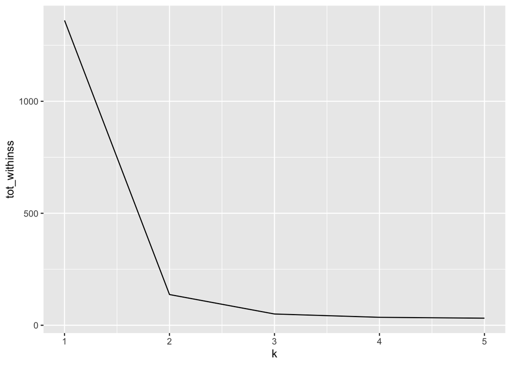

```r
#--- calculate Total within-cluster sum of squares
DF2.tot_withinss <- map_dbl(1:5,  function(k){
  model <- kmeans(DF2.matrix, centers = k)
  model$tot.withinss
})


#--- Generate a data frame containing both k and tot_withinss
DF2.elbow_df <- data.frame(
  k = 1:5,
  tot_withinss = DF2.tot_withinss
)


#--- Plot the elbow plot of K values and tot_withinss
ggplot(DF2.elbow_df, aes(x = k, y = tot_withinss)) +
  geom_line() +
  scale_x_continuous(breaks = 1:5)
```

```r
#--- the elbow plot looks like 2 groups... maybe 3 groups for good measure


#--- kmeans the datatable into 2 groups
DF2.groups <- kmeans(DF2.matrix, centers = 2)

DF2.clustered <- data.frame(DF2, cluster = as.factor(DF2.groups$cluster))


DF2.clustered <- cbind(DF2.clustered,time = DF1[,2])


#--- Can you identify the novices from the experts using only the app data?
#--- pressure: generally, higher pressure value was associated with slowest speed
#--- audio: generally, lower audio value was associated with slower speed
```

Visualize your results using ggplot2

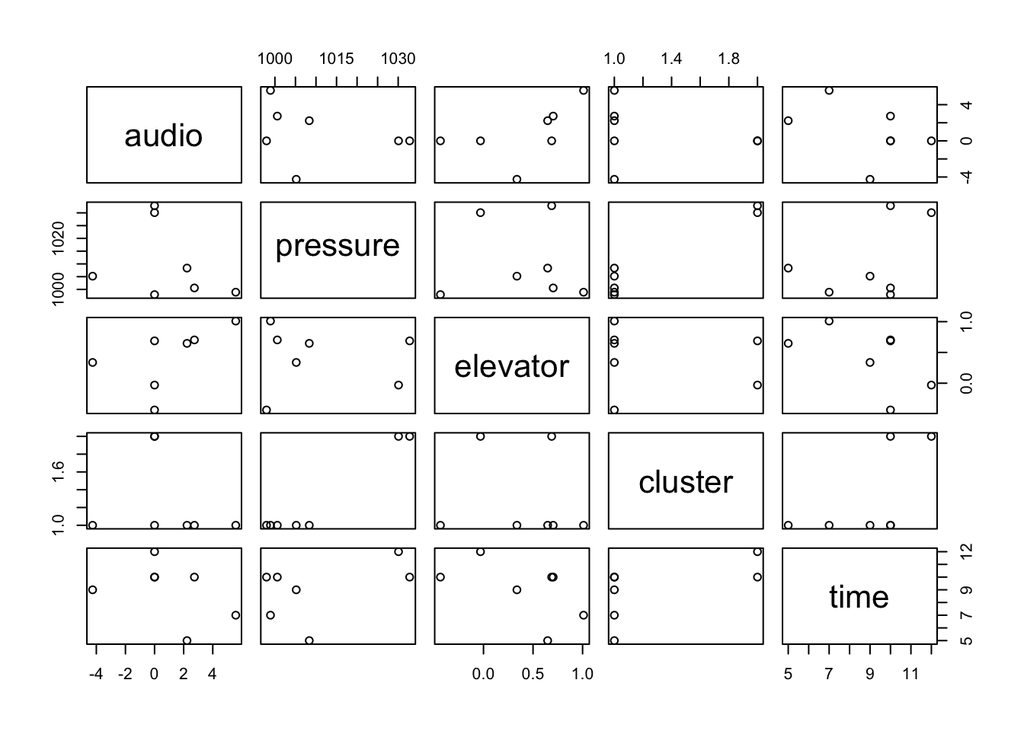

```r
#--- Let's take a look

DF3.clustered <- DF2.clustered
DF3.clustered$cluster <- as.numeric(DF3.clustered$cluster)

pairs(DF3.clustered)
```

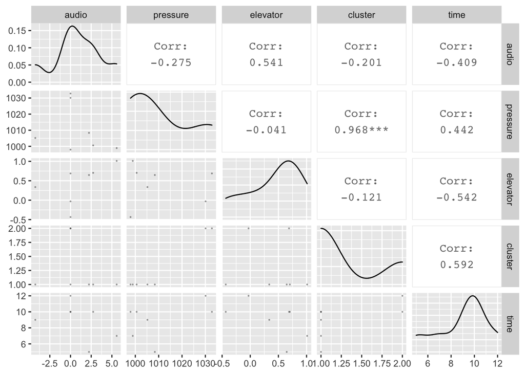

```r
ggpairs(DF3.clustered,
          progress = FALSE,
          lower = list(continuous = wrap("points", alpha = 0.3, size=0.2)))
```

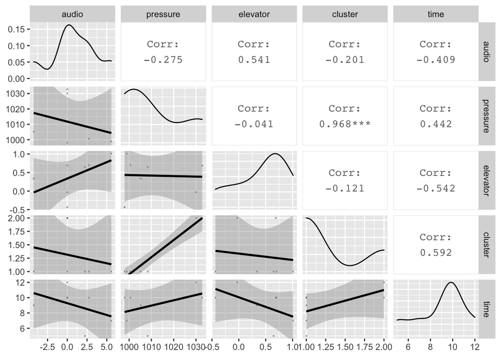

```r
ggpairs(DF3.clustered,
          progress = FALSE,
          lower = list(continuous = wrap("smooth", alpha = 0.3, size=0.2)))
```

Task III Devise five questions on a five point Likert scale that ask members of your group about their experience with your chosen task

```r
#--- Question 1: the task was... fun
#--- Question 2: the task was... easy
#--- Question 3: the task was... confusing
#--- Question 4: the task was... fast
#--- Question 5: the task was... embarrassing

#--- (1) Strongly disagree; (2) Disagree; (3) Neither agree nor disagree; (4) Agree; (5) Strongly agree
```

Collect data from all members of your group

```r
#---- read in the data
SV1 <- read.csv("survey1.csv")

#---- what do we have?...
str(SV1)
```

```
## 'data.frame':    7 obs. of  6 variables:
##  $ Person: chr  "Jiacong Zhu" "Xiaojia Liu" "Fei Wang" "Berj Akian" ...
##  $ Q1    : int  4 5 4 4 4 4 5
##  $ Q2    : int  4 4 5 5 5 4 4
##  $ Q3    : int  4 3 3 3 4 3 3
##  $ Q4    : int  3 3 4 5 4 4 3
##  $ Q5    : int  5 4 5 5 4 4 5
```

```r
head(SV1)
```

```
##        Person Q1 Q2 Q3 Q4 Q5
## 1 Jiacong Zhu  4  4  4  3  5
## 2 Xiaojia Liu  5  4  3  3  4
## 3    Fei Wang  4  5  3  4  5
## 4  Berj Akian  4  5  3  5  5
## 5  Xijia Wang  4  5  4  4  4
## 6 Guoliang Xu  4  4  3  4  4
```

```r
#summary(DF1)

#---- na's please rise... https://sebastiansauer.github.io/sum-isna/
SV1.is.na <- DF1 %>%
  summarise_all(funs(sum(is.na(.))))
SV1.is.na
```

```
##   person time audio pressure elevator
## 1      0    0     0        0        0
```

```r
sum(SV1.is.na)
```

```
## [1] 0
```

```r
#---- drop rows that contain NA in any column... if needed based on results of previous command... not needed
#SV2 <- na.omit(SV1)
```

Run a PCA analysis on the data

```r
#--- commence dimension reduction
SV1.pca <- prcomp(SV1[2:6], scale. = TRUE, center = TRUE)

SV1.pca$sdev
```

```
## [1] 1.5332016 1.1113704 0.9774004 0.6161759 0.2813614
```

```r
SV1.pca$sdev^2
```

```
## [1] 2.35070727 1.23514425 0.95531150 0.37967273 0.07916424
```

```r
summary(SV1.pca)
```

```
## Importance of components:
##                           PC1    PC2    PC3     PC4     PC5
## Standard deviation     1.5332 1.1114 0.9774 0.61618 0.28136
## Proportion of Variance 0.4701 0.2470 0.1911 0.07593 0.01583
## Cumulative Proportion  0.4701 0.7172 0.9082 0.98417 1.00000
```

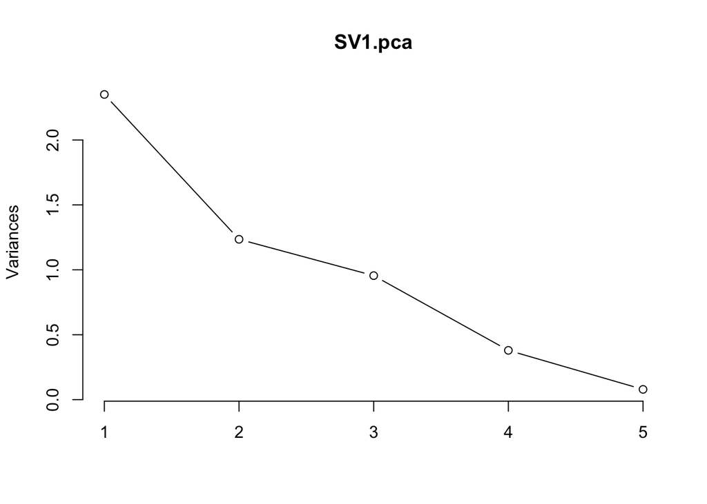

```r
plot(SV1.pca, type = "lines")
```